# Module 6: Bayesian Methods for Clinical Research - Computational Methods & Application

Rebecca Hubbard, Lurdes Inoue

July 24, 2017

### Install R

- Go to http://cran.rstudio.com/
- Click on the “Download R for [operating system]” link that is appropriate for your operating system and follow the instructions.
- Open R and make sure it works (i.e. that no error messages come up)

### Install RStudio

- Go to http://www.rstudio.com/products/rstudio/download/
- Select the installer that is appropriate for your operating system under “Installers for Supported Platforms” and follow the instructions.
- Open RStudio and make sure it works.

### Install R Packages

- For this module we will be using the *INLA* and *rjags* packages for Bayesian estimation
- We will also be using the *eha* and *survival* packages for survival regression
- To use these packages you first need to install them using *install.packages()*

```r
install.packages("INLA", repos="https://www.math.ntnu.no/inla/R/stable")
install.packages("rjags")
install.packages("eha")
install.packages("survival")
```

- You then need to load these libraries:

```r
library(INLA)
library(rjags)
library(eha)
library(survival)
```

- After the first time you install the packages on your computer, you will only need to load the libraries in the future

### Introduction to Bayesian Computing

#### Bayesian GLMs using INLA

In this lab, we will conduct an analysis using a Bayesian logistic and survival regression models estimated with INLA. We will use data from the Western Collaborative Group Study (WCGS), a study of the association between cardiovascular health and behavioral pattern conducted in a cohort of male volunteers. Subjects were recruited in 1960-1961 and followed for up to 9 years for onset of coronary heart disease (CHD). The scientific question of interest is whether behavioral pattern is associated with CHD. Specifically, investigators hypothesized that men with a “Type A” behavioral pattern would be more likely to experience CHD. Because this is an observational study design it is important to account for confounding due to many factors such as cigarette smoking and elevated BMI.

We will use the following variables from this data set:

- age Age: age in years
- behpat Behavior pattern: (A1, A2, B3, B4)
- bmi Body mass index
- chd Indicator of CHD at any time during follow-up: 0 = no; 1 = yes
- chd01 Coronary heart disease within 5 years: 0 = no; 1 = yes
- chol Cholesterol: mg/100 ml
- dbp Diastolic blood pressure: mm Hg
- dibpat Dichotomous behavior pattern: 0 = Type B; 1 = Type A
- height Height: height in inches
- id Subject ID
- ncigs Smoking: Cigarettes/day
- sbp Systolic blood pressure: mm Hg
- time Time in days from baseline to onset of CHD
- smoke: No = non-smoker; Yes = current smoker
- weight Weight: pounds

You can download the data file and read it into R as follows:

```r
wcgs <- read.csv("https://raw.githubusercontent.com/rhubb/SISCR2017/master/data/wcgs.csv", header = T)
```

1. We will start by using logistic regression to analyze the association between behavioral pattern and onset of CHD within 5 years of baseline (*chd01*). Begin by conducting an exploratory data analysis to summarize the distribution of CHD, behavioral pattern, and possible confounders included in the data set. What conclusions do you reach regarding the role that number of cigarettes, BMI, and age may play in the analysis of the association between CHD and behavioral pattern?

   ```r
   #-- univariate tables for categorical variables
   table(wcgs$chd01)/sum(table(wcgs$chd01))
   ```

   ```
   ##
   ##          0          1
   ## 0.95624604 0.04375396
   ```

   ```r
   table(wcgs$behpat)/sum(table(wcgs$behpat))
   ```

   ```
   ##
   ##         A1         A2         B3         B4
   ## 0.08370323 0.42010146 0.38554217 0.11065314
   ```

   ```r
   table(wcgs$smoke)/sum(table(wcgs$smoke))
   ```

   ```
   ##
   ##        No       Yes
   ## 0.5237793 0.4762207
   ```

   ```r
   ##-- bivariate tables for categorical predictors and CHD
   # CHD and behavioral pattern
   table(wcgs$behpat,wcgs$chd01)
   ```

   ```
   ##
   ##         0    1
   ##   A1  244   20
   ##   A2 1245   80
   ##   B3 1186   30
   ##   B4  341    8
   ```

   ```r
   t(sweep(table(wcgs$chd01,wcgs$behpat),2,rowSums(table(wcgs$behpat,wcgs$chd01)),"/"))
   ```

   ```
   ##
   ##               0          1
   ##   A1 0.92424242 0.07575758
   ##   A2 0.93962264 0.06037736
   ##   B3 0.97532895 0.02467105
   ##   B4 0.97707736 0.02292264
   ```

   ```r
   # CHD and smoking
   table(wcgs$smoke,wcgs$chd01)
   ```

   ```
   ##
   ##          0    1
   ##   No  1602   50
   ##   Yes 1414   88
   ```

   ```r
   t(sweep(table(wcgs$chd01,wcgs$smoke),2,rowSums(table(wcgs$smoke,wcgs$chd01)),"/"))
   ```

   ```
   ##
   ##                0          1
   ##   No  0.96973366 0.03026634
   ##   Yes 0.94141145 0.05858855
   ```

   ```r
   # Behavioral pattern and smoking
   table(wcgs$behpat,wcgs$smoke)
   ```

   ```
   ##
   ##       No Yes
   ##   A1 130 134
   ##   A2 654 671
   ##   B3 658 558
   ##   B4 210 139
   ```

   ```r
   t(sweep(table(wcgs$smoke,wcgs$behpat),2,rowSums(table(wcgs$behpat,wcgs$smoke)),"/"))
   ```

   ```
   ##
   ##             No       Yes
   ##   A1 0.4924242 0.5075758
   ##   A2 0.4935849 0.5064151
   ##   B3 0.5411184 0.4588816
   ##   B4 0.6017192 0.3982808
   ```

   ```r
   ##-- summary statistics for continuous variables by CHD
   # Age
   tapply(wcgs$age,wcgs$chd01,mean)
   ```

   ```
   ##        0        1
   ## 46.15981 48.87681
   ```

   ```r
   tapply(wcgs$age,wcgs$chd01,sd)
   ```

   ```
   ##        0        1
   ## 5.485787 5.735601
   ```

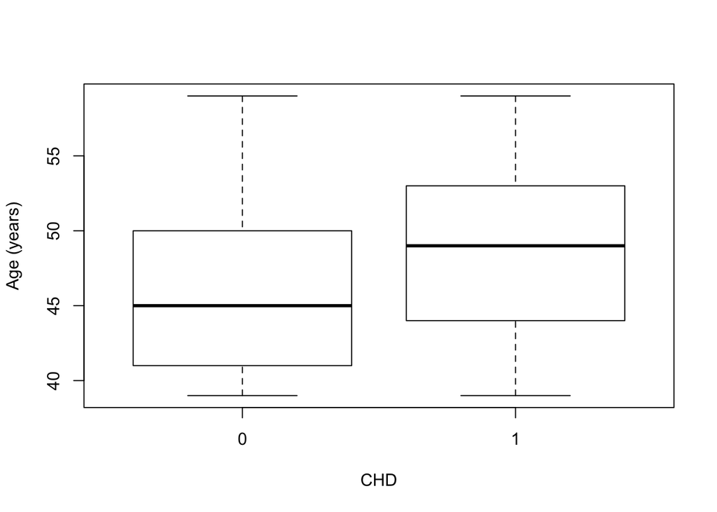

   ```r
   boxplot(wcgs$age ~ wcgs$chd01, xlab = "CHD", ylab = "Age (years)")
   ```

   ```r
   # BMI
   tapply(wcgs$bmi,wcgs$chd01,mean)
   ```

   ```
   ##        0        1
   ## 24.48469 25.25447
   ```

   ```r
   tapply(wcgs$bmi,wcgs$chd01,sd)
   ```

   ```
   ##        0        1
   ## 2.555605 2.722124
   ```

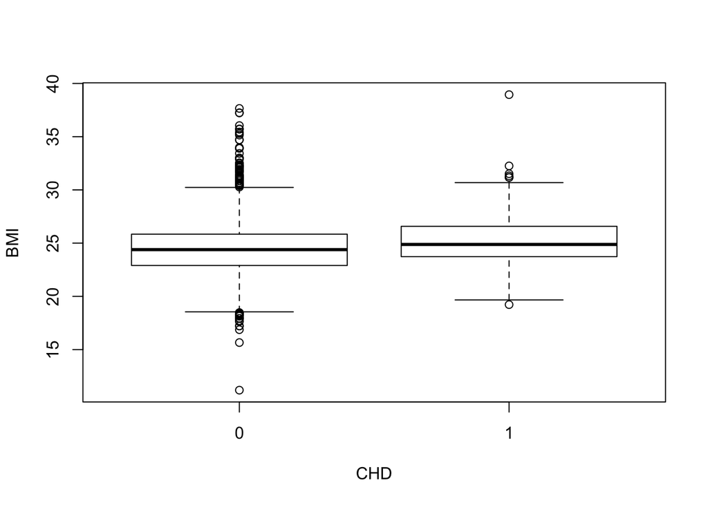

   ```r
   boxplot(wcgs$bmi ~ wcgs$chd01, xlab = "CHD", ylab = "BMI")
   ```

   ```r
   # Number of cigarettes
   tapply(wcgs$ncigs,wcgs$chd01,mean)
   ```

   ```
   ##        0        1
   ## 11.32825 17.55072
   ```

   ```r
   tapply(wcgs$ncigs,wcgs$chd01,sd)
   ```

   ```
   ##        0        1
   ## 14.38932 16.01873
   ```

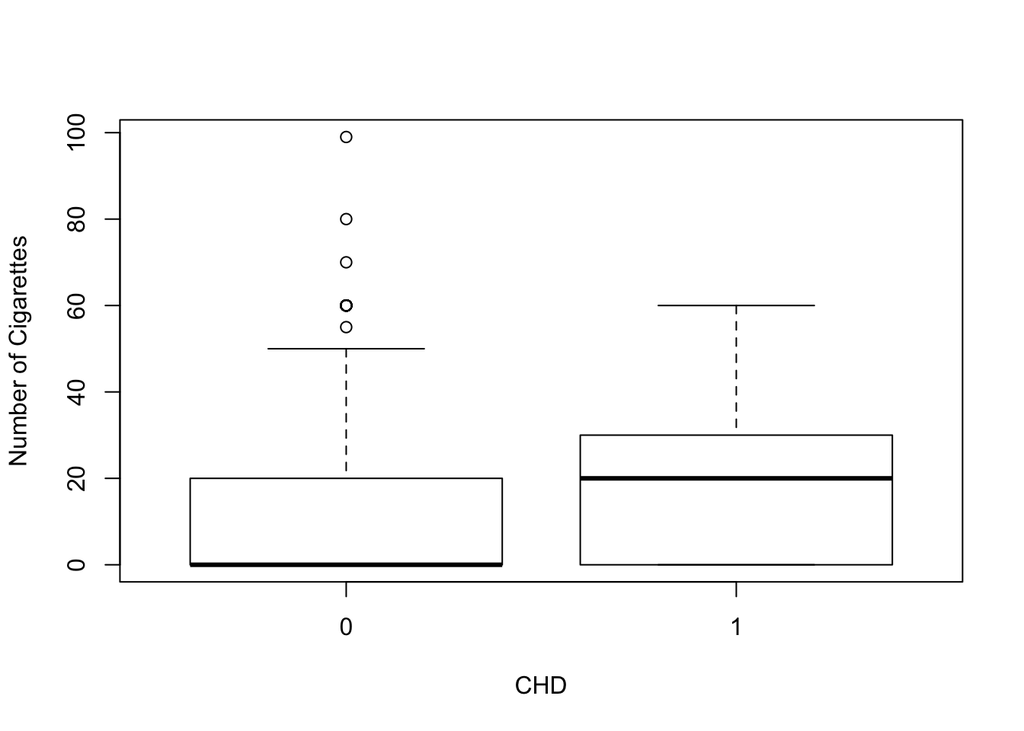

   ```r
   boxplot(wcgs$ncigs ~ wcgs$chd01, xlab = "CHD", ylab = "Number of Cigarettes")
   ```

2. Next, use Bayesian logistic regression to analyze the association between CHD and behavioral pattern, accounting for possible confounders based on your results from (1). We will explore results using several prior distributions. For each prior distribution can you think of a context in which this prior would be preferred? Compare your results to a standard frequentist logistic regression. How does the interpretation of the results differ for the Bayesian GLM compared to the frequentist GLM?
1. Normal(0,10) priors

   ```r
   ## -- Normal priors for regression coefficients (with mean=0 and scale=10)
   chd.n10 <- inla(chd01~ factor(behpat) + smoke + age, data=wcgs, family = "binomial",
        control.fixed=list(mean.intercept=c(0),prec.intercept=c(1/10),mean=c(0,0),prec=rep(1/10,2)))

   chd.n10$summary.fix
   ```

   ```
   ##                         mean         sd  0.025quant    0.5quant  0.975quant        mode          kld
   ## (Intercept)      -6.26698930 0.77253282 -7.79571677 -6.26299507 -4.76173552 -6.25490663 2.976434e-14
   ## factor(behpat)A2 -0.20042304 0.25772195 -0.69002068 -0.20635600  0.32305049 -0.21839737 6.669412e-12
   ## factor(behpat)B3 -1.04992030 0.29532389 -1.62269265 -1.05237486 -0.46362931 -1.05729354 1.826691e-13
   ## factor(behpat)B4 -1.07064068 0.42176348 -1.93539435 -1.05774250 -0.27761325 -1.03159432 1.312570e-11
   ## smokeYes          0.63885813 0.18134192  0.28692285  0.63742893  0.99860933  0.63456638 1.472819e-13
   ## age               0.07008238 0.01477483  0.04108423  0.07007856  0.09907514  0.07007215 0.000000e+00
   ```

2. Normal(0,0.1) priors

   ```r
   ## -- Normal priors for regression coefficients (with mean=0 and scale=0.1), N(0,10) prior for intercept
   chd.n01 <- inla(chd01~ factor(behpat) + smoke + age, data=wcgs, family = "binomial",
        control.fixed=list(mean.intercept=c(0),prec.intercept=c(1/10),mean=c(0,0),prec=rep(10,2)))

   chd.n01$summary.fix
   ```

   ```
   ##                         mean         sd  0.025quant    0.5quant 0.975quant       mode          kld
   ## (Intercept)      -6.65890005 0.73900197 -8.12035019 -6.65539141 -5.2181843 -6.6482815 1.626331e-14
   ## factor(behpat)A2  0.17896201 0.18485468 -0.18156346  0.17811742  0.5438312  0.1764347 1.726030e-14
   ## factor(behpat)B3 -0.49613956 0.19979112 -0.88893232 -0.49596586 -0.1046685 -0.4956001 5.215058e-16
   ## factor(behpat)B4 -0.33246318 0.23612445 -0.80232291 -0.33035296  0.1253376 -0.3260915 2.513968e-13
   ## smokeYes          0.49442389 0.15528680  0.19117847  0.49384901  0.8005730  0.4927065 8.632616e-15
   ## age               0.07198376 0.01466979  0.04318775  0.07198136  0.1007667  0.0719778 0.000000e+00
   ```

3. Frequentist logistic regression

   ```r
   chd.glm1 <- glm(chd01~ factor(behpat) + smoke + age, data=wcgs, family=binomial)
   summary(chd.glm1)
   ```

   ```
   ##
   ## Call:
   ## glm(formula = chd01 ~ factor(behpat) + smoke + age, family = binomial,
   ##     data = wcgs)
   ##
   ## Deviance Residuals:
   ##     Min       1Q   Median       3Q      Max
   ## -0.6571  -0.3355  -0.2474  -0.1958   3.0328
   ##
   ## Coefficients:
   ##                  Estimate Std. Error z value Pr(>|z|)
   ## (Intercept)      -6.62666    0.80397  -8.242  < 2e-16 ***
   ## factor(behpat)A2 -0.17295    0.26262  -0.659 0.510167
   ## factor(behpat)B3 -1.01842    0.30052  -3.389 0.000702 ***
   ## factor(behpat)B4 -1.04604    0.43024  -2.431 0.015045 *
   ## smokeYes          0.65496    0.18269   3.585 0.000337 ***
   ## age               0.07709    0.01524   5.059 4.21e-07 ***
   ## ---
   ## Signif. codes:  0 '***' 0.001 '**' 0.01 '*' 0.05 '.' 0.1 ' ' 1
   ##
   ## (Dispersion parameter for binomial family taken to be 1)
   ##
   ##     Null deviance: 1133.5  on 3153  degrees of freedom
   ## Residual deviance: 1065.1  on 3148  degrees of freedom
   ## AIC: 1077.1
   ##
   ## Number of Fisher Scoring iterations: 6
   ```

   ```r
   ## -- Exponentiate results to obtain odds ratios
   exp(chd.n10$summary.fix)
   ```

   ```
   ##                         mean       sd   0.025quant   0.5quant  0.975quant        mode kld
   ## (Intercept)      0.001897934 2.165243 0.0004114937 0.00190553 0.008550757 0.001921005   1
   ## factor(behpat)A2 0.818384469 1.293979 0.5015656984 0.81354340 1.381335094 0.803805969   1
   ## factor(behpat)B3 0.349965639 1.343561 0.1973665435 0.34910768 0.628996672 0.347394748   1
   ## factor(behpat)B4 0.342788830 1.524648 0.1443673267 0.34723882 0.757589760 0.356438232   1
   ## smokeYes         1.894316573 1.198825 1.3323214200 1.89161117 2.714504217 1.886204063   1
   ## age              1.072596537 1.014885 1.0419398618 1.07259244 1.104149266 1.072585569   1
   ```

4. Since some individuals were censored prior to the end of follow-up, a more appropriate way to analyze these data is with survival analysis. Analyze the association between time to onset of CHD and behavioral pattern, adjusting for the same confounders used in your logistic regression model using:
1. Cox proportional hazards model

   ```r
   chd.cph <- coxph(Surv(time, chd) ~ factor(behpat) + smoke + age, data=wcgs)
   summary(chd.cph)
   ```

   ```
   ## Call:
   ## coxph(formula = Surv(time, chd) ~ factor(behpat) + smoke + age,
   ##     data = wcgs)
   ##
   ##   n= 3154, number of events= 257
   ##
   ##                      coef exp(coef) se(coef)      z Pr(>|z|)
   ## factor(behpat)A2  0.01256   1.01264  0.20052  0.063 0.950049
   ## factor(behpat)B3 -0.75571   0.46968  0.22378 -3.377 0.000733 ***
   ## factor(behpat)B4 -0.70152   0.49583  0.29916 -2.345 0.019028 *
   ## smokeYes          0.57514   1.77737  0.12865  4.470 7.80e-06 ***
   ## age               0.06831   1.07070  0.01078  6.334 2.38e-10 ***
   ## ---
   ## Signif. codes:  0 '***' 0.001 '**' 0.01 '*' 0.05 '.' 0.1 ' ' 1
   ##
   ##                  exp(coef) exp(-coef) lower .95 upper .95
   ## factor(behpat)A2    1.0126     0.9875    0.6835    1.5002
   ## factor(behpat)B3    0.4697     2.1291    0.3029    0.7283
   ## factor(behpat)B4    0.4958     2.0168    0.2759    0.8912
   ## smokeYes            1.7774     0.5626    1.3812    2.2871
   ## age                 1.0707     0.9340    1.0483    1.0936
   ##
   ## Concordance= 0.684  (se = 0.018 )
   ## Rsquare= 0.032   (max possible= 0.722 )
   ## Likelihood ratio test= 102.4  on 5 df,   p=0
   ## Wald test            = 99.14  on 5 df,   p=0
   ## Score (logrank) test = 104.2  on 5 df,   p=0
   ```

2. Parametric survival regression

   ```r
   chd.weib <- weibreg(Surv(time, chd) ~ factor(behpat) + smoke + age, data=wcgs)
   summary(chd.weib)
   ```

   ```
   ## Call:
   ## weibreg(formula = Surv(time, chd) ~ factor(behpat) + smoke +
   ##     age, data = wcgs)
   ##
   ## Covariate           Mean       Coef Exp(Coef)  se(Coef)    Wald p
   ## factor(behpat)
   ##               A1    0.080     0         1           (reference)
   ##               A2    0.410     0.020     1.021     0.200     0.919
   ##               B3    0.395    -0.761     0.467     0.224     0.001
   ##               B4    0.114    -0.691     0.501     0.299     0.021
   ## smoke
   ##               No    0.532     0         1           (reference)
   ##              Yes    0.468     0.577     1.780     0.129     0.000
   ## age                46.181     0.067     1.069     0.011     0.000
   ##
   ## log(scale)                   12.225 203820.234     0.500     0.000
   ## log(shape)                    0.276     1.318     0.060     0.000
   ##
   ## Events                    257
   ## Total time at risk        8464892
   ## Max. log. likelihood      -2870.8
   ## LR test statistic         102
   ## Degrees of freedom        5
   ## Overall p-value           0
   ```

3. Bayesian non-parametric survival model

   ```r
   chd.np <- inla(inla.surv(time, chd) ~ factor(behpat) + smoke + age, family="coxph",data=wcgs)
   summary(chd.np)
   ```

   ```
   ##
   ## Call:
   ## c("inla(formula = cph$formula, family = cph$family, contrasts = contrasts, ",  "    data = c(as.list(cph$data), cph$data.list), quantiles = quantiles, ",  "    E = cph$E, offset = offset, scale = scale, weights = inla.ifelse(missing(weights) || ",  "        (exists(\"weights\") && is.function(wei…
   ##
   ## Time used:
   ##  Pre-processing    Running inla Post-processing           Total
   ##          0.7270         66.9579          0.2277         67.9127
   ##
   ## Fixed effects:
   ##                      mean     sd 0.025quant 0.5quant 0.975quant     mode kld
   ## (Intercept)      -13.5298 0.5709   -14.6570 -13.5277   -12.4151 -13.5235   0
   ## factor(behpat)A2   0.0189 0.2005    -0.3610   0.0139     0.4272   0.0037   0
   ## factor(behpat)B3  -0.7589 0.2238    -1.1890  -0.7620    -0.3104  -0.7684   0
   ## factor(behpat)B4  -0.6925 0.2991    -1.2919  -0.6884    -0.1165  -0.6800   0
   ## smokeYes           0.5762 0.1286     0.3256   0.5755     0.8304   0.5740   0
   ## age                0.0672 0.0108     0.0461   0.0672     0.0883   0.0673   0
   ##
   ## Random effects:
   ## Name   Model
   ##  baseline.hazard   RW1 model
   ##
   ## Model hyperparameters:
   ##                                   mean    sd 0.025quant 0.5quant 0.975quant     mode
   ## Precision for baseline.hazard 10244.45 23.43   10205.08 10245.23   10283.04 10244.88
   ##
   ## Expected number of effective parameters(std dev): 9.641(0.0095)
   ## Number of equivalent replicates : 3991.95
   ##
   ## Marginal log-Likelihood:  -1749.98
   ```

   ```r
   exp(chd.np$summary.fix)
   ```

   ```
   ##                          mean       sd   0.025quant     0.5quant   0.975quant         mode kld
   ## (Intercept)      1.330723e-06 1.769928 4.310869e-07 1.333474e-06 4.056965e-06 1.339080e-06   1
   ## factor(behpat)A2 1.019083e+00 1.221986 6.969870e-01 1.013995e+00 1.533023e+00 1.003737e+00   1
   ## factor(behpat)B3 4.681965e-01 1.250803 3.045257e-01 4.667136e-01 7.331807e-01 4.637395e-01   1
   ## factor(behpat)B4 5.003137e-01 1.348609 2.747531e-01 5.023996e-01 8.899900e-01 5.066383e-01   1
   ## smokeYes         1.779236e+00 1.137289 1.384919e+00 1.777968e+00 2.294333e+00 1.775440e+00   1
   ## age              1.069544e+00 1.010825 1.047150e+00 1.069551e+00 1.092354e+00 1.069566e+00   1
   ```

4. Bayesian parametric survival model

   ```r
   chd.weib <- inla(inla.surv(time, chd) ~ factor(behpat) + smoke + age, family="weibullsurv",data=wcgs)
   summary(chd.weib)
   ```

   ```
   ##
   ## Call:
   ## c("inla(formula = inla.surv(time, chd) ~ factor(behpat) + smoke + ",  "    age, family = \"weibullsurv\", data = wcgs)")
   ##
   ## Time used:
   ##  Pre-processing    Running inla Post-processing           Total
   ##          0.4747          4.9694          0.1158          5.5598
   ##
   ## Fixed effects:
   ##                      mean     sd 0.025quant 0.5quant 0.975quant     mode kld
   ## (Intercept)      -15.8788 0.8205   -17.5057 -15.8719   -14.2910 -15.8570   0
   ## factor(behpat)A2   0.0207 0.2005    -0.3591   0.0157     0.4291   0.0056   0
   ## factor(behpat)B3  -0.7595 0.2238    -1.1897  -0.7627    -0.3110  -0.7691   0
   ## factor(behpat)B4  -0.6901 0.2991    -1.2894  -0.6859    -0.1141  -0.6775   0
   ## smokeYes           0.5761 0.1286     0.3256   0.5754     0.8304   0.5740   0
   ## age                0.0668 0.0108     0.0457   0.0668     0.0879   0.0668   0
   ##
   ## The model has no random effects
   ##
   ## Model hyperparameters:
   ##                                  mean     sd 0.025quant 0.5quant 0.975quant mode
   ## alpha parameter for weibullsurv 1.285 0.0688      1.155    1.283      1.422 1.28
   ##
   ## Expected number of effective parameters(std dev): 6.001(0.00)
   ## Number of equivalent replicates : 525.55
   ##
   ## Marginal log-Likelihood:  -2903.95
   ```

   ```r
   exp(chd.weib$summary.fix)
   ```

   ```
   ##                          mean       sd   0.025quant     0.5quant   0.975quant         mode kld
   ## (Intercept)      1.270332e-07 2.271663 2.496754e-08 1.279183e-07 6.215757e-07 1.298378e-07   1
   ## factor(behpat)A2 1.020952e+00 1.221978 6.982760e-01 1.015854e+00 1.535821e+00 1.005574e+00   1
   ## factor(behpat)B3 4.678892e-01 1.250801 3.043273e-01 4.664068e-01 7.326996e-01 4.634339e-01   1
   ## factor(behpat)B4 5.015394e-01 1.348595 2.754317e-01 5.036305e-01 8.921532e-01 5.078795e-01   1
   ## smokeYes         1.779097e+00 1.137285 1.384819e+00 1.777829e+00 2.294140e+00 1.775300e+00   1
   ## age              1.069111e+00 1.010819 1.046740e+00 1.069118e+00 1.091899e+00 1.069133e+00   1
   ```

### Interim Monitoring of Clinical Trials